# Coffee consumption in USYD Undergraduates

Project 3

490356641, 480048691

University of Sydney | DATA1001 | April 2019

# 1 Executive Summary

An article by The Washington Post called [What’s real and what’s myth when it comes to caffeine?](https://www.washingtonpost.com/lifestyle/wellness/whats-real-and-whats-myth-when-it-comes-to-caffeine/2016/07/07/ad2087ca-3f09-11e6-84e8-1580c7db5275_story.html?noredirect=on&utm_term=.c48efa326b82) distinguishes fact from fiction regarding coffee consumption. Some of these include addiction to coffee, the effect of coffee on sleep, etc.

The aim of this report is to summarize a study that focused on proving some of these hypotheses and testing out new theories regarding coffee consumption by carrying out a survey directed towards undergraduate students in the University of Sydney. For instance, do students in higher years of study tend to consume coffee more frequently? Does drinking coffee within 6 hours of going to bed have an effect on sleeping patterns? And is there, perhaps, a correlation between frequency of coffee consumption and contact hours?

The main discoveries are that the higher the year of study the students are in, the more days they consume coffee per week. Secondly, those that drink coffee within 6 hours of sleeping tend to get less hours of sleep per night than those that don’t. And finally, there seems to be no relationship between coffee consumption and contact hours. However, care needs to be taken in determining conclusions for each question due to hidden confounding factors.

# 2 Full Report

## 2.1 Initial Data Analysis (IDA)

**Quick look at top 5 rows of data**

```r
head(data)
```

```
##   Age Gender Which.year.of.study.are.you.in.
## 1  19 Female                          Year 1
## 2  19 Female                          Year 2
## 3  22 Female                          Year 5
## 4  24 Female                          Year 5
## 5  23 Female                          Year 2
## 6  18   Male                          Year 1
##   How.many.hours.of.lectures..labs.and.tutorials.do.you.usually.go.to.each.week.
## 1                                                                              6
## 2                                                                             15
## 3                                                                              9
## 4                                                                             10
## 5                                                                             30
## 6                                                                             13
##   How.many.hours.of.sleep.do.you.have.per.day.
```

[output cut: 48 more lines]

**Size of data**

```r
dim(data)
```

```
## [1] 63 12
```

**R’s classification of data**

```r
class(data)
```

```
## [1] "data.frame"
```

**R’s classification of variables**

```r
str(data)
```

```
## 'data.frame':    63 obs. of  12 variables:
##  $ Age                                                                                : int  19 19 22 24 23 18 22 19 19 17 ...
##  $ Gender                                                                             : Factor w/ 2 levels "Female","Male": 1 1 1 1 1 2 1 1 1 1 ...
##  $ Which.year.of.study.are.you.in.                                                    : Factor w/ 5 levels "Year 1","Year 2",..: 1 2 5 5 2 1 2 2 1 1 ...
##  $ How.many.hours.of.lectures..labs.and.tutorials.do.you.usually.go.to.each.week.     : int  6 15 9 10 30 13 18 14 10 23 ...
##  $ How.many.hours.of.sleep.do.you.have.per.day.                                       : int  7 7 5 6 7 5 6 6 8 5 ...
##  $ Do.you.lead.an.active.lifestyle...e.g..play.sports..go.to.the.gym.every.week..etc..: logi  FALSE TRUE TRUE FALSE TRUE FALSE ...
##  $ How.many.cups.of.coffee.do.you.have.per.day.                                       : int  1 0 1 0 0 1 1 1 0 1 ...
##  $ On.an.average..how.many.days.per.week.do.you.have.coffee.                          : int  3 0 5 0 0 2 6 2 2 2 ...
##  $ Do.you.drink.coffee.within.6.hours.before.going.to.sleep.                          : logi  TRUE FALSE FALSE FALSE FALSE FALSE ...
##  $ Why.do.you.drink.coffee.                                                           : Factor w/ 11 levels "I don't drink coffee",..: 7 1 7 8 2 5 9 2 10 9 ...
##  $ Submitted.At                                                                       : Factor w/ 63 levels "4/14/2019 10:03:16",..: 26 27 28 29 30 31 32 33 34 35 ...
##  $ Token                                                                              : Factor w/ 63 levels "0118dbbe0069f72c8453c7878c61a70c",..: 29 46 60 43 40 19 42 50 47 7 ...
```

```r
sapply(data, class)
```

```
##                                                                                 Age
##                                                                           "integer"
##                                                                              Gender
##                                                                            "factor"
##                                                     Which.year.of.study.are.you.in.
##                                                                            "factor"
##      How.many.hours.of.lectures..labs.and.tutorials.do.you.usually.go.to.each.week.
##                                                                           "integer"
##                                        How.many.hours.of.sleep.do.you.have.per.day.
##                                                                           "integer"
## Do.you.lead.an.active.lifestyle...e.g..play.sports..go.to.the.gym.every.week..etc..
##                                                                           "logical"
##                                        How.many.cups.of.coffee.do.you.have.per.day.
##                                                                           "integer"
##                           On.an.average..how.many.days.per.week.do.you.have.coffee.
##                                                                           "integer"
##                           Do.you.drink.coffee.within.6.hours.before.going.to.sleep.
##                                                                           "logical"
##                                                            Why.do.you.drink.coffee.
##                                                                            "factor"
##                                                                        Submitted.At
##                                                                            "factor"
##                                                                               Token
##                                                                            "factor"
```

### 2.1.1 Stakeholders

According to the Food Regulation Standing Committee (2013), the average caffeine content in a flat white is 86.9 mg / 100 ml. Typical serving size for regular take-away cups in Australia is approximately 280 ml (Food Standards, 2019). A healthy amount of caffeine per day for a healthy adult is up to 400 mg (Wikoff, D. et al.). Accordingly, 2 regular-sized cups of coffee per day can be deemed as healthy. However, there are no regulations on serving size of retail units, therefore, the amount of caffeine can vary greatly in different serving cups.

Given this information, this dataset is valuable for government health authority to help raise awareness of the adverse effects of coffee (or caffeine in general) associated with continued use. It is also helpful for any data scientist wanting to apply machine learning in predicting students’ daily sleeping patterns given their coffee consumption habits, gender, and year of study.

### 2.1.2 Survey Design

**Methodology**  
The study uses distributing questionnaire as a primary research method. With respect to the aim of gaining quantitative data on USYD student’s coffee consumption, sleeping patterns, and weekly contact hours, questionnaires were distributed through different social media platforms including Facebook, WeChat, and Edstem. Moreover, secondary research method is integrated throughout the report as it provides important domain knowledge of the topic.

**Survey questions**  
The questionnaire can be viewed here: https://thaophamm.typeform.com/to/GyzHE7 (more about each questions in the survey)

**Limitations**  
There were a total of 63 participants in this study. However, a sample size of 63 for a total number of undergraduate students of around 34,000 is a gross underrepresentation of the total population. So, although this study was a randomized study, the sample size was too small and thus, it cannot be used as a representation of the total population.

**Data integrity**  
Distributing the questionnaire through different social media platforms ensured there was randomisation in sampling and no selection bias. Therefore, all USYD undergraduates had an equal chance to participate in the study. However, there may be volunteer bias as some students may choose not to participate in the study. In addition, coverage bias is an issue since 58.73% of the partcipants are in year 1. Therefore, the data set is not representative of the population, and since all factors could not be controlled, the data set is not valid either.

**Ethical issues**  
The study attempted to eliminate ethical issues by ensuring anonymity of the participants. Moreover, those who completed the survey gave their consent for their information to be used in this report.

## 2.2 Is there a correlation between coffee consumption and year of study?

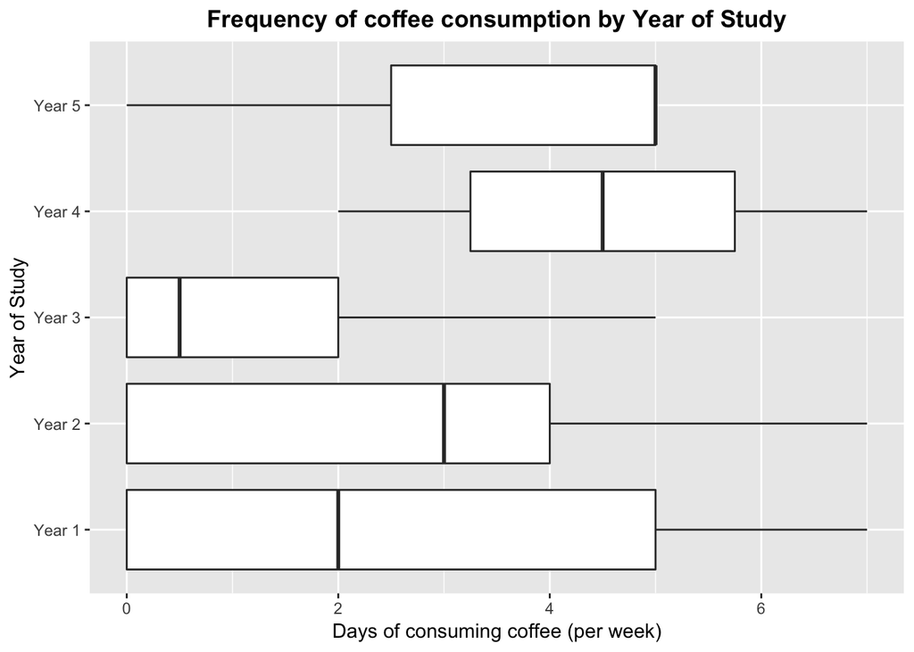

```r
coffee_2_boxplot = ggplot(data, aes(year, coffeeweekly))

coffee_2_boxplot + geom_boxplot() +
  labs(x = "Year of Study", y = "Days of consuming coffee (per week)") +
  coord_flip() +
  ggtitle("Frequency of coffee consumption by Year of Study") +
  theme(plot.title = element_text(hjust = 0.5, face = "bold"))
```

**Percentage of year 1 students**

```r
sum(year=="Year 1") / length(year) * 100
```

```
## [1] 58.73016
```

**Percentage of year 2 students**

```r
sum(year=="Year 2") / length(year) * 100
```

```
## [1] 26.98413
```

**Percentage of year 3 students**

```r
sum(year=="Year 3") / length(year) * 100
```

```
## [1] 6.349206
```

**Percentage of year 4 students**

```r
sum(year=="Year 4") / length(year) * 100
```

```
## [1] 3.174603
```

**Percentage of year 5 students**

```r
sum(year=="Year 5") / length(year) * 100
```

```
## [1] 4.761905
```

The box plot above shows coffee consumption in days per week for undergraduate students in each year of study (Year 1 to Year 5).

From the graph, it can be seen that the higher the year of study the student is in, the more days per week they drink coffee. Other than the data for Year 3, there seems to be a general overall positive trend in the median coffee consumption per week for each year of study. As shown, the median coffee intake for 1st years is 2 days per week and that for 5th years is 5 days per week.

Perhaps this could be a sign of dependence on coffee because as the students graduate each year, they are faced with more intense workload so they are more likely to resort to coffee to keep up in class (stimulant). However, as mentioned in the article by The Washington Post, even though caffeine does not stimulate the brain circuit of dependence, the American Psychiatric Association has included caffeine withdrawal as a syndrome.

Once again, care needs to be taken in making conclusions as there might be other variables that may confound the results, such as whether the student is a full-time or a part-time student, how many credit points they are taking, etc.

**Summary:** In short, there seems to be a positive correlation between year of study and coffee consumed in days per week. However, conclusions made have to be treated carefully due to confounding factors.

## 2.3 Does drinking coffee within 6 hours of going to bed have an effect on sleeping patterns?

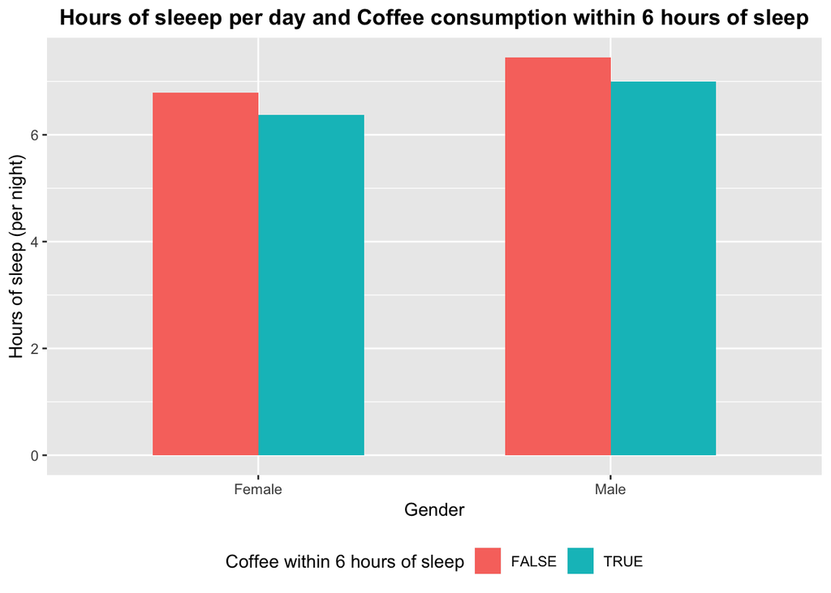

```r
bar_sleep = ggplot(data, aes(gender, sleep, fill = coffee6))

bar_sleep + stat_summary(fun.y = mean, geom = "bar", position = "dodge", width = 0.6) +
  labs(x = "Gender", y = "Hours of sleep (per night)", fill = "Coffee within 6 hours of sleep") +
  ggtitle("Hours of sleeep per day and Coffee consumption within 6 hours of sleep") +
  theme(legend.position = "bottom") +
  theme(plot.title = element_text(hjust = 0.5, face ="bold"))
```

**Total number of students**

```r
length(gender)
```

```
## [1] 63
```

**Percentage of male students**

```r
sum(gender=="Male") / length(gender) * 100
```

```
## [1] 41.26984
```

**Percentage of female students**

```r
sum(gender=="Female") / length(gender) * 100
```

```
## [1] 58.73016
```

**Percentage of students who drink coffee within 6 hours of going to bed**

```r
sum(coffee6=="TRUE") / length(coffee6) * 100
```

```
## [1] 25.39683
```

**Percentage of students who do not drink coffee within 6 hours of going to bed**

```r
sum(coffee6=="FALSE") / length(coffee6) * 100
```

```
## [1] 74.60317
```

The sample population of the dataset consists of 63 undergraduate students from the University of Sydney, of which 41.2% are male and 58.7% are female.

The bar plot above displays two trends in the hours of sleep the students get per night:

1. Male students tend to get more hours of sleep per night than female students.
2. For both genders, it is apparent that people who drink coffee within six hours of going to bed (green bar) get less sleep per night than people who do not (red bar).

This supports the point made in the article by The Washington Post that there is a correlation between coffee consumption and impaired sleep. In other words, caffeine (which is a stimulant) decreases both the total hours of sleep as well as the quality of sleep.

However, there may be hidden confounding factors such as insomnia and workload that may affect the hours of sleep students get per night. There is also coverage bias as 74.6% of the participants do not drink coffee within six hours of going to sleep. Hence, any conclusions made cannot be 100% definite.

**Summary:** Although the bar plot shows a clear trend, definite conclusions cannot be made due to lurking variables.

## 2.4 Is there a correlation between coffee consumption and contact hours?

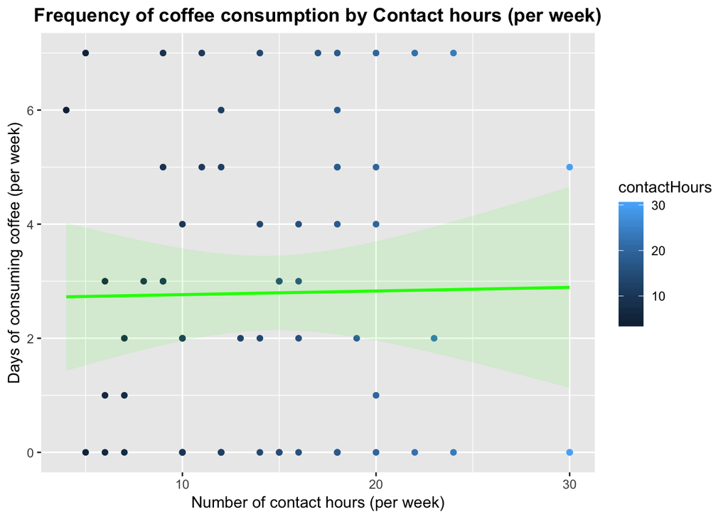

```r
scatter = ggplot(data, aes(contactHours, coffeeweekly, colour = contactHours))

scatter + geom_point() +
  geom_smooth(method = "lm", alpha = 0.1, colour = "Green", fill = "Green") +
  labs(x = "Number of contact hours (per week)", y = "Days of consuming coffee (per week)") +
  ggtitle("Frequency of coffee consumption by Contact hours (per week)") +
  theme(plot.title = element_text(hjust = 0.5, face = "bold"))
```

```r
l = lm(coffeeweekly ~ contactHours)
summary(l)
```

```
##
## Call:
## lm(formula = coffeeweekly ~ contactHours)
##
## Residuals:
##     Min      1Q  Median      3Q     Max
## -2.8920 -2.7647 -0.7456  2.1844  4.2672
##
## Coefficients:
##              Estimate Std. Error t value Pr(>|t|)
## (Intercept)  2.701005   0.838150   3.223  0.00204 **
## contactHours 0.006365   0.053028   0.120  0.90485
## ---
## Signif. codes:  0 '***' 0.001 '**' 0.01 '*' 0.05 '.' 0.1 ' ' 1
##
## Residual standard error: 2.593 on 61 degrees of freedom
## Multiple R-squared:  0.0002361,  Adjusted R-squared:  -0.01615
## F-statistic: 0.01441 on 1 and 61 DF,  p-value: 0.9049
```

```r
l$coefficients
```

```
##  (Intercept) contactHours
##  2.701004858  0.006364988
```

**Correlation**

```r
cor(contactHours, coffeeweekly)
```

```
## [1] 0.0153666
```

The scatter plot above shows the relationship between contact hours and the consumption of coffee in days per week.

For `x = contact_hours` and `y = coffee_weekly`, the regression line (green) is approximately
$$y = 2.7 + 0.006x$$
The green area around it is the confidence interval.

In other words, if contact hour increases by 1, coffee consumption increases by 0.006 days per week (on an average). Additionally, the correlation coefficient for the two variables is 0.015, indicating an almost non-existent linear association between them.

Furthermore, the multiple R-squared value for the regression line is 0.0002361. This means that only 0.02% of the variance found in the frequency of consuming coffee (per week) can be explained by contact hours. Hence, knowing a student’s contact hours will not help us make a prediction about their days of consuming coffee per week.

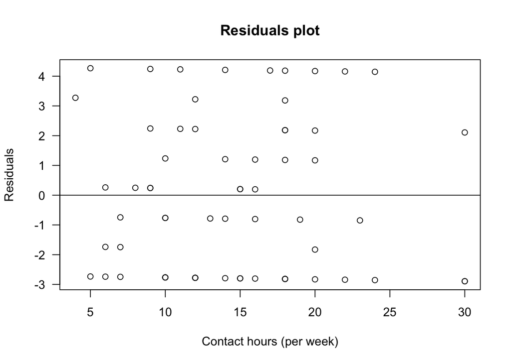

```r
## For x = coffeeweekly and y = contacthours
plot(contactHours, l$residuals, main = "Residuals plot", xlab = "Contact hours (per week)", ylab = "Residuals", las = 1)
abline(h = 0)
```

In this residual plot, the data appears to be randomly distributed about zero. However, given the nature of the data collected on days of consuming coffee (discrete quantitative data) and the low R-squared value, it can be concluded that linear regression is not a well-suited model to analyse this particular relationship.

Moreover, there may be hidden confounders that may affect the relationship between the two variables (e.g. units of study, extracurricular activities). Therefore, no definite conclusions can be made.

**Summary:** There seems to be no correlation between contact hours and coffee consumption in days per week. Moreover, the linear model for this graph is not appropriate and hence, no predictions can be made.

# 3 References

- Australia Bureau of Statistics. (May 2014). *Australian Health Survey: Nutrition First Results – Food and Nutrients, 2011-12*. Retrieved from: http://www.abs.gov.au/AUSSTATS/abs@.nsf/Lookup/4364.0.55.007Main+Features12011-12?OpenDocument
- Bermam, J. (July 2016). *What’s real and what’s myth when it comes to caffeine?* The Washington Post. Retrieved from: https://www.washingtonpost.com/lifestyle/wellness/whats-real-and-whats-myth-when-it-comes-to-caffeine/2016/07/07/ad2087ca-3f09-11e6-84e8-1580c7db5275_story.html?utm_term=.6a02f6290c3a
- Food Standards Australia & New Zealand (2019). *Takeaway coffee cup measures program.* Retrieved from: http://www.foodstandards.gov.au/science/monitoringnutrients/ausnut/foodmeasures/Pages/Takeaway-beverage-measures-program---data-table.aspx
- Ratini, M. (April 2017). *Caffeine Myths and Facts*. WebMD Medical Reference. Retrieved from: https://www.webmd.com/diet/caffeine-myths-and-facts#1
- Wikoff, D. et al. (November 2017). *Systematic review of the potential adverse effects of caffeine consumption in healthy adults, pregnant women, adolescents, and children*. Food and Chemical Technology. Retrieved from: https://doi.org/10.1016/j.fct.2017.04.002